# 8: Testing

R for faculty, Fall 2024

Jonas Moss

# Testing

## Install the `datarium` package

If you haven’t already, install the package.

```r
install.packages("datarium")
```

## Paired *t*-test

- Data
- The paired *t*-test
- Exercise
- Solution

```r
mice2 = tibble::as_tibble(datarium::mice2)
mice2
```

```
# A tibble: 10 × 3
      id before after
   <int>  <dbl> <dbl>
 1     1   187.  430.
 2     2   194.  404.
 3     3   232.  406.
 4     4   200.  397.
 5     5   202.  378.
 6     6   235   446.
 7     7   209.  408.
 8     8   172.  337
 9     9   185.  414.
10    10   190.  380.
```

```r
mice2_test = t.test(mice2$before, mice2$after, paired = TRUE)
mice2_test
```

```
    Paired t-test

data:  mice2$before and mice2$after
t = -25.546, df = 9, p-value = 1.039e-09
alternative hypothesis: true mean difference is not equal to 0
95 percent confidence interval:
 -217.1442 -181.8158
sample estimates:
mean difference
        -199.48
```

Use the `str` function to inspect `mice2_test`. Extract the *p*-value. Why would you do this?

```r
str(mice2_test)
```

```
List of 10
 $ statistic  : Named num -25.5
  ..- attr(*, "names")= chr "t"
 $ parameter  : Named num 9
  ..- attr(*, "names")= chr "df"
 $ p.value    : num 1.04e-09
 $ conf.int   : num [1:2] -217 -182
  ..- attr(*, "conf.level")= num 0.95
 $ estimate   : Named num -199
  ..- attr(*, "names")= chr "mean difference"
 $ null.value : Named num 0
  ..- attr(*, "names")= chr "mean difference"
 $ stderr     : num 7.81
 $ alternative: chr "two.sided"
 $ method     : chr "Paired t-test"
 $ data.name  : chr "mice2$before and mice2$after"
 - attr(*, "class")= chr "htest"
```

```r
mice2_test$p.value
```

```
[1] 1.038922e-09
```

## Two-sample *t*-test

- Data
- Test
- Exercise
- Solution

```r
weight = datarium::genderweight
head(weight)
```

```
# A tibble: 6 × 3
  id    group weight
  <fct> <fct>  <dbl>
1 1     F       61.6
2 2     F       64.6
3 3     F       66.2
4 4     F       59.3
5 5     F       64.9
6 6     F       65.0
```

```r
females = weight$weight[weight$group == "F"]
males = weight$weight[weight$group == "M"]
ts_test = t.test(males, females)
```

Use `str` to inspect; alternatively, use the console. Find the *t*-value of the test. (Often reported in, e.g., psychology.)

```r
ts_test$statistic
```

```
       t
20.79138
```

## Chi square test

- Data
- Table
- `chisq_test``
- Exercise
- Solution

```r
properties = datarium::properties
head(properties)
```

```
# A tibble: 6 × 2
  property_type buyer_type
  <fct>         <fct>
1 flat          single male
2 flat          single male
3 flat          single male
4 flat          single male
5 flat          single male
6 flat          single male
```

Are `property_type` and `buyer_type` independent?

```r
tab <- table(properties$property_type, properties$buyer_type)
tab
```

```
                 single male single female married couple family
  flat                    40            30             16     10
  bungalow                 4             4             14     16
  detached house           8            16             26     42
  terrace                 16             7             45     39
```

```r
chisq_test <- chisq.test(tab)
chisq_test
```

```
    Pearson's Chi-squared test

data:  tab
X-squared = 82.504, df = 9, p-value = 5.134e-14
```

Find out how to access the *p*-value and `X-squared` of the preceeding test. Store them in the variables `pval` and `x_squared`.

```r
# str(chisq_test)
pval <- chisq_test$p.value
x_squared <- chisq_test$statistic
```

## Correlation test

```r
cor.test(mice2$after, mice2$before)
```

```
    Pearson's product-moment correlation

data:  mice2$after and mice2$before
t = 2.0035, df = 8, p-value = 0.08008
alternative hypothesis: true correlation is not equal to 0
95 percent confidence interval:
 -0.08113628  0.88541183
sample estimates:
      cor
0.5780184
```

- Exercise
- Solution

Using the `datarium::anxiety` data set, test if the correlation between `t1` and `t2` is significantly different from `0`. Store the resulting *p*-value inside the variable `pval`.

```r
val <- cor.test(datarium::anxiety$t1, datarium::anxiety$t2)
pval <- val$p.value
```

## Kolmogorov–Smirmov test

- Data
- Histogram
- ECDF
- KS test
- Exercise
- Solution
- Exercise
- Solution

```r
jobsatisfaction <- datarium::jobsatisfaction
summary(jobsatisfaction)
```

```
       id        gender     education_level     score
 1      : 1   male  :28   school    :19     Min.   : 4.780
 2      : 1   female:30   college   :19     1st Qu.: 5.800
 3      : 1               university:20     Median : 6.380
 4      : 1                                 Mean   : 6.963
 5      : 1                                 3rd Qu.: 8.515
 6      : 1                                 Max.   :10.000
 (Other):52
```

Are the distributions different?

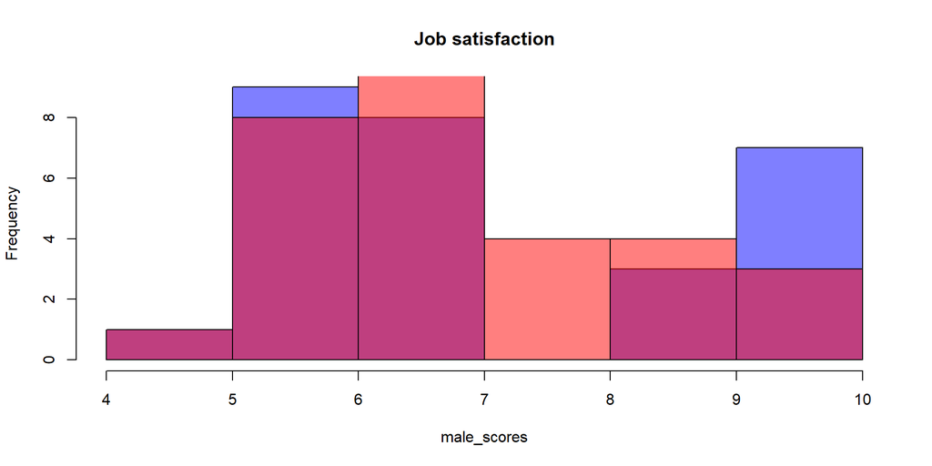

```r
male_scores <- jobsatisfaction$score[jobsatisfaction$gender == "male"]
female_scores <- jobsatisfaction$score[jobsatisfaction$gender == "female"]
hist(male_scores, col = rgb(0, 0, 1, 0.5), main = "Job satisfaction")
hist(female_scores, col = rgb(1, 0, 0, 0.5), add = TRUE)
```

Are the distributions different? (ECDF: Empirical cumulative distribution)

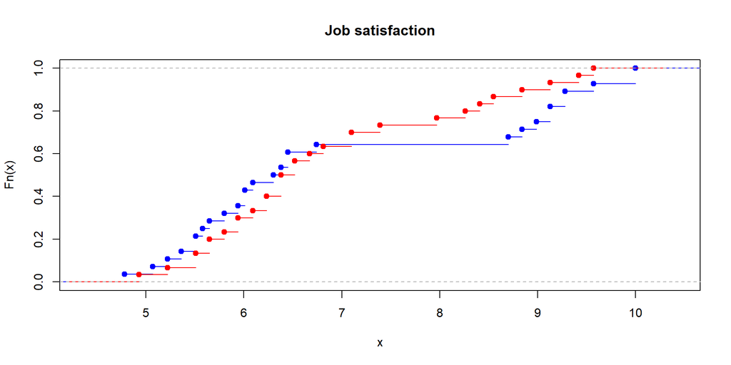

```r
male_scores <- jobsatisfaction$score[jobsatisfaction$gender == "male"]
female_scores <- jobsatisfaction$score[jobsatisfaction$gender == "female"]
plot(ecdf(male_scores), col = "blue", main = "Job satisfaction")
plot(ecdf(female_scores), col = "red", add = TRUE)
```

```r
ks.test(male_scores, female_scores)
```

```
    Exact two-sample Kolmogorov-Smirnov test

data:  male_scores and female_scores
D = 0.22381, p-value = 0.3449
alternative hypothesis: two-sided
```

Run a *t*-test to figure out if male job satisfaction is significantly different from female job satisfaction.

```r
t.test(male_scores, female_scores)
```

```
    Welch Two Sample t-test

data:  male_scores and female_scores
t = 0.47084, df = 49.769, p-value = 0.6398
alternative hypothesis: true difference in means is not equal to 0
95 percent confidence interval:
 -0.6311159  1.0175445
sample estimates:
mean of x mean of y
 7.063214  6.870000
```

Are the distributions of the scores significantly different for the two levels of education? Use a plot and the Kolomogorov–Smirnov test.

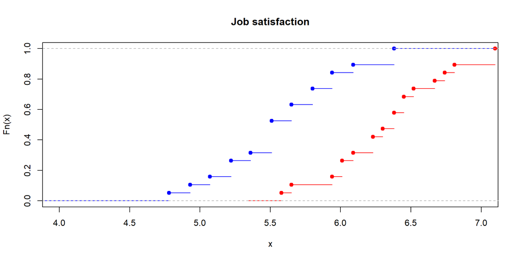

```r
education <- jobsatisfaction$education_level
school_score <- jobsatisfaction$score[education == "school"]
college_score <- jobsatisfaction$score[education == "college"]
plot(ecdf(school_score), col = "blue", main = "Job satisfaction", xlim = c(4, 7))
plot(ecdf(college_score), col = "red", add = TRUE)
```

```r
ks.test(school_score, college_score)
```

```
    Exact two-sample Kolmogorov-Smirnov test

data:  school_score and college_score
D = 0.68421, p-value = 0.000111
alternative hypothesis: two-sided
```

# Summary

1. `R` supports most basic tests.
2. More specialized tests, e.g., the Dickey–Fuller test for unit roots is in the `tseries` library.
3. Inspect the test objects to find the information you need.
- Some external libraries are, of course, unreliable.
- Others are not ideally constructed, so that you cannot access the information you need. But this is rate.